# Get started with `rhub`

In this article you’ll learn how to use `rhub` to connect to the R-hub builder API to start new checks and get the results and artifacts of recent checks.

```r
library(rhub)
```

## Validate your email address

To build and check packages, first you need to validate your email address with `validate_email()`.

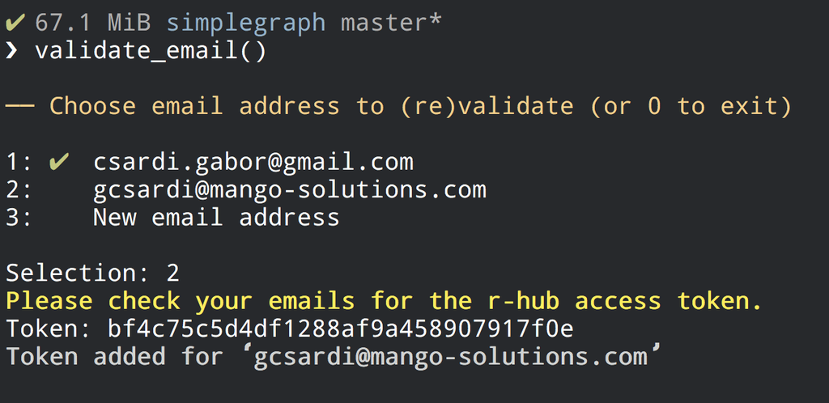

The package tries to detect your email address using [`whoami`](https://github.com/r-lib/whoami#whoami) (note that `whoami` does so using your global git config) and the maintainer email listed in DESCRIPTION; and if it fails to do this correctly, you’ll need to specify it. This means that if running `validate_email()` gives an error, you should either run `validate_email("youremail@example.com")` ( quickest fix), or edit your global git config (less quick, but useful for package development in general; to set it up smoothly [refer to this `usethis` helper](https://usethis.r-lib.org/articles/articles/usethis-setup.html#configure-user-name-and-user-emails)).

`rhub` stores the token permanently on the machine, so you do not need to validate your email again. You can also copy your token to other machines: run `list_validated_emails()` to get the token, and use the `validate_email()` function on the new machine, using both the `email` and `token` arguments.

Currently you cannot use the token obtained via this function in the Web UI of the R-hub builder.

## Run a package check

`check()` runs an `R CMD check` on the package in the specified directory, or specified source R package tarball created by `R CMD build` or `devtools::build()`. It defaults to the working directory.

```r
check()
```

If the `platform` argument is NULL, and the R session is interactive, then a menu is shown. If it is NULL, and the session is not interactive, then the default R-hub platform `platforms()$name[1]`, i.e. debian-gcc-devel, is used.

In interactive R sessions, the output of the check is printed to the screen unless you set the `show_status` argument to `FALSE`. Therefore, by default, your R session is busy showing the log until the check is finished, so set `show_status` to `FALSE` if you want to submit a check and then go on with your work in the same session.

In all cases, you will receive a notification email with results after the check.

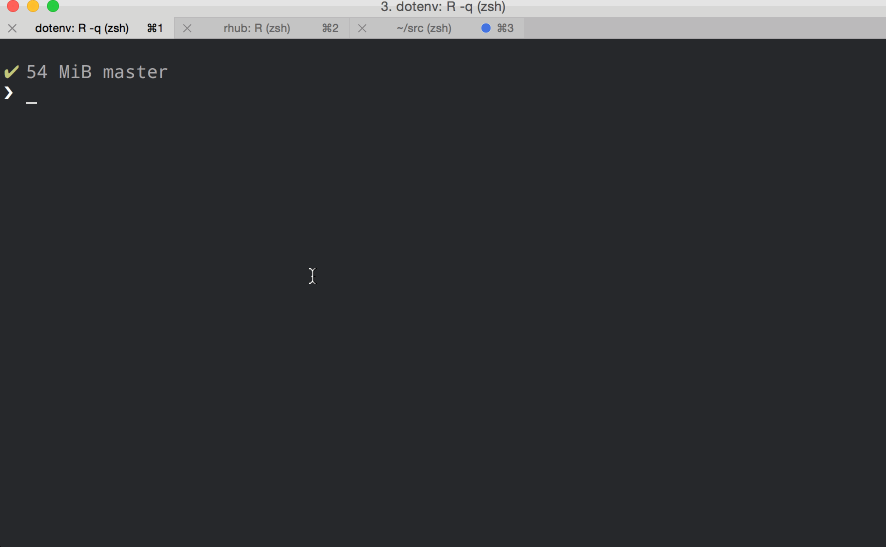

You can either just run the function, or assign its output to an object, that you can use to print results to the screen, to browse the web page of the check, and to retrieve URLs to the web page of the check but also to its artifacts that are kept a few days.

```r
mycheck <- check()
mycheck$browse()
mycheck$print()
mycheck$livelog()
mycheck$urls()
```

To retrieve such objects from previous checks, see the corresponding section.

## Select a building and checking architecture

You can run checks on any platform. You can use the platform ids (e.g. `"debian-gcc-devel"` or `c("debian-gcc-devel", "debian-gcc-patched")`) to select between platforms. You should not run checks on all platforms at once. E.g. if preparing for a CRAN submission, use the shortcut function `check_for_cran()` that will submit your package to a few recommended platforms. The following subsections give more info on how to select platforms.

### Listing R-hub platforms

If looking for a platform with particular characteristics, in particular to reproduce a result from CRAN’s own platform, have a look at the R-hub platform characteristics.

```r
knitr::kable(platforms(), row.names = FALSE)
```

| name | description | cran-name | rversion | os-type | cpu-type | os-info | compilers | docker-image | sysreqs-platform | categories | node-labels | output-parser | macos-version |
| --- | --- | --- | --- | --- | --- | --- | --- | --- | --- | --- | --- | --- | --- |
| debian-gcc-devel | Debian Linux, R-devel, GCC | r-devel-linux-x86_64-debian-gcc | r-devel | Linux | x86_64 | Debian GNU/Linux testing | GCC 6.2.0 (Debian 6.2.0-6) | debian-gcc-devel | linux-x86_64-debian-gcc | Linux | linux | NA | NA |
| debian-gcc-patched | Debian Linux, R-patched, GCC | r-patched-linux-x86_64 | r-patched | Linux | x86_64 | Debian GNU/Linux testing | GCC 6.2.0 (Debian 6.2.0-6) | debian-gcc-patched | linux-x86_64-debian-gcc | Linux | linux | NA | NA |
| debian-gcc-release | Debian Linux, R-release, GCC | r-release-linux-x86_64 | r-release | Linux | x86_64 | Debian GNU/Linux testing | GCC 6.2.0 (Debian 6.2.0-6) | debian-gcc-release | linux-x86_64-debian-gcc | Linux | linux | NA | NA |
| fedora-clang-devel | Fedora Linux, R-devel, clang, gfortran | r-devel-linux-x86_64-fedora-clang | r-devel | Linux | x86_64 | Fedora 24 | clang version 3.8.0; GNU Fortran 6.1.1 | fedora-clang-devel | linux-x86_64-fedora-clang | Linux | linux | NA | NA |
| fedora-gcc-devel | Fedora Linux, R-devel, GCC | r-devel-linux-x86_64-fedora-gcc | r-devel | Linux | x86_64 | Fedora 24 | GCC 6.1.1 | fedora-gcc-devel | linux-x86_64-fedora-gcc | Linux | linux | NA | NA |
| linux-x86_64-centos6-epel | CentOS 6, stock R from EPEL | NA | r-release | Linux | x86_64 | CentOS 6 | GCC 4.4.x | centos6-epel | linux-x86_64-centos6-epel | Linux | linux | NA | NA |
| linux-x86_64-centos6-epel-rdt | CentOS 6 with Redhat Developer Toolset, R from EPEL | NA | r-release | Linux | x86_64 | CentOS 6 | GCC 5.2.1 | centos6-epel-rdt | linux-x86_64-centos6-epel | Linux | linux | NA | NA |
| linux-x86_64-rocker-gcc-san | Debian Linux, R-devel, GCC ASAN/UBSAN | NA | r-devel | Linux | x86_64 | Debian GNU/Linux testing | GCC 5.4.0 (Debian 5.4.0-4) | rocker-gcc-san | linux-x86_64-debian-gcc | Checks for compiled code | linux | sanitizers | NA |
| macos-elcapitan-release | macOS 10.11 El Capitan, R-release (experimental) | r-release-osx-x86_64 | r-release | macOS | x86_64 | Mac OS X 10.11.6 15G1217 | Apple LLVM version 8.0 (clang-800.0.42.1); GNU Fortran 4.2.3 | NA | osx-x86_64-clang | macOS | c(“macos”, “elcapitan”, “r-release”) | NA | elcapitan |
| macos-mavericks-oldrel | macOS 10.9 Mavericks, R-oldrel (experimental) | r-oldrel-osx-x86_64 | r-oldrel | macOS | x86_64 | Mac OS X 10.9.5 13F1911 | Apple LLVM version 6.0 (clang-600.0.57); GNU Fortran 4.2.3 | NA | osx-x86_64-clang | macOS | c(“macos”, “mavericks”, “r-oldrel”) | NA | mavericks |
| solaris-x86-patched | Oracle Solaris 10, x86, 32 bit, R-patched (experimental) | r-patched-solaris-x86 | r-patched | Solaris | x86_64 | SunOS 5.10 Generic_147148-26 i86pc i386 i86pc | GCC 5.2.0 | NA | solaris-10 | Solaris | solaris | NA | NA |
| ubuntu-gcc-devel | Ubuntu Linux 16.04 LTS, R-devel, GCC | NA | r-devel | Linux | x86_64 | Ubuntu 16.04 LTS | GCC 5.3.1 | ubuntu-gcc-devel | linux-x86_64-ubuntu-gcc | Linux | linux | NA | NA |
| ubuntu-gcc-release | Ubuntu Linux 16.04 LTS, R-release, GCC | NA | r-release | Linux | x86_64 | Ubuntu 16.04 LTS | GCC 5.3.1 | ubuntu-gcc-release | linux-x86_64-ubuntu-gcc | Linux | linux | NA | NA |
| ubuntu-rchk | Ubuntu Linux 16.04 LTS, R-devel with rchk | NA | r-devel | Linux | x86_64 | Ubuntu 16.04 LTS | clang 3.8.0-2ubuntu4 | ubuntu-rchk | linux-x86_64-ubuntu-gcc | Checks for compiled code | linux | rchk | NA |
| windows-x86_64-devel | Windows Server 2008 R2 SP1, R-devel, 32/64 bit | r-devel-windows-ix86+x86_64 | r-devel | Windows | x86_64 | Windows Server 2008 R2 SP1 | GCC 4.9.3, Rtools 3.4 | NA | windows-2008 | Windows | c(“windows”, “rtools3”) | NA | NA |
| windows-x86_64-devel-rtools4 | Windows Server 2012, R-devel, Rtools4.0, 32/64 bit (experimental) | NA | r-testing | Windows | x86_64 | Windows Server 2012 | Rtools 4.0 | NA | windows-2012 | Windows | c(“windows”, “rtools4.0”) | NA | NA |
| windows-x86_64-oldrel | Windows Server 2008 R2 SP1, R-oldrel, 32/64 bit | r-oldrel-windows-ix86+x86_64 | r-oldrel | Windows | x86_64 | Windows Server 2008 R2 SP1 | GCC 4.6.3, Rtools 3.3 | NA | windows-2008 | Windows | c(“windows”, “rtools3”) | NA | NA |
| windows-x86_64-patched | Windows Server 2008 R2 SP1, R-patched, 32/64 bit | NA | r-patched | Windows | x86_64 | Windows Server 2008 R2 SP1 | GCC 4.9.3, Rtools 3.4 | NA | windows-2008 | Windows | c(“windows”, “rtools3”) | NA | NA |
| windows-x86_64-release | Windows Server 2008 R2 SP1, R-release, 32/64 bit | r-release-windows-ix86+x86_64 | r-release | Windows | x86_64 | Windows Server 2008 R2 SP1 | GCC 4.9.3, Rtools 3.4 | NA | windows-2008 | Windows | c(“windows”, “rtools3”) | NA | NA |

### Shortcuts for quick checks

These are quick shortcuts that select the right platform(s):

### Sanitizers for compiled code

R-hub provides a special Docker image to run Address Sanitizer (ASAN) and Undefined Behavior Sanitizer (UBSAN). This is based on the `r-devel-san` image of the [Rocker project](https://github.com/rocker-org/r-devel-san).

This image does not run `R CMD check` at all, but it runs

1. package tests,
2. all manual examples, and
3. all vignette code

with ASAN and UBSAN enabled. Use it via `check_with_sanitizers()`.

## Browse previous checks

Once a check is finished (or failed), you will get a notification email but you can also get information from R. E.g. you could submit a check for a package located at `<package-path>`, then turn off your computer and on the following days retrieve results via

```r
previous_checks <- rhub::list_package_checks(<package-path>,
                                  email = "maelle.salmon@yahoo.se",
                                  howmany = 4)
previous_checks
```

```r
# A tibble: 10 x 13
   package version result group   id      platform_name build_time
   <chr>   <chr>   <rhub> <rhub:> <rhub:> <chr>         <time>
 1 note    1.0     NN     e863a86 00c375b windows-x86_… ~1m
 2 note    1.0     NN     e863a86 5d67129 fedora-clang… ~1m
 3 note    1.0     NN     e863a86 61a7543 ubuntu-gcc-r… ~53.2s
 4 note    1.0     NN     a99e137 197fd0e fedora-clang… ~46s
 5 note    1.0     NN     a99e137 2ed7302 windows-x86_… ~1m
 6 note    1.0     NN     a99e137 88293d9 ubuntu-gcc-r… ~36.7s
 7 note    1.0     NN     9ceef8e 4f9113c windows-x86_… ~1m
 8 note    1.0     NN     9ceef8e 6761ed2 ubuntu-gcc-r… ~35.9s
 9 note    1.0     N      9ceef8e f8bc9d2 fedora-clang… ~57.9s
10 note    1.0     ok     d3b8509 d3b8509 debian-gcc-d… ~45.5s
# … with 6 more variables: submitted <dttm>, started <dttm>, platform <list>,
#   builder <chr>, status <rhub::status>, email <chr>
```

You can then extract checks from this list using their `group` ID (ID for checks submitted simultaneously e.g. via `check_for_cran()`) or `id` (check id). In both cases you’ll get a `rhub_check` object.

Here’s an example where we extract the last group of checks, print it to the screen, and query its URLs.

```r
group_id <- previous_checks$group[1]
group_check <- rhub::get_check(group_id)
group_check
```

```r
── note 1.0: NOTE

  Build ID:   note_1.0.tar.gz-00c375b187024da7a32c27ef94fa8832
  Platform:   Windows Server 2008 R2 SP1, R-devel, 32/64 bit
  Submitted:  4d 1h 44m 17.5s ago
  Build time: 1m 46.2s

❯ checking CRAN incoming feasibility ... NOTE
  Maintainer: 'Ma�lle Salmon <maelle.salmon@yahoo.se>'

  New submission
  The Description field contains

    <http://http://cran.r-project.org/doc/manuals/r-release/R-exts.html#The-DESCRIPTION-file>
  Please enclose URLs in angle brackets (<...>).

  The Date field is over a month old.

❯ checking R code for possible problems ... NOTE
  .bello: no visible global function definition for 'tail'
  Undefined global functions or variables:
    tail
  Consider adding
    importFrom("utils", "tail")
  to your NAMESPACE file.

0 errors ✔ | 0 warnings ✔ | 2 notes ✖

── note 1.0: NOTE

  Build ID:   note_1.0.tar.gz-5d6712942ce243dcb8d34f7bdfc8ccc6
  Platform:   Fedora Linux, R-devel, clang, gfortran
  Submitted:  4d 1h 44m 17.6s ago
  Build time: 1m 7.2s

❯ checking CRAN incoming feasibility ... NOTE
  Maintainer: ‘Maëlle Salmon <maelle.salmon@yahoo.se>’

  New submission

  The Description field contains
    <http://http://cran.r-project.org/doc/manuals/r-release/R-exts.html#The-DESCRIPTION-file>
  Please enclose URLs in angle brackets (<...>).

  The Date field is over a month old.

❯ checking R code for possible problems ... NOTE
  .bello: no visible global function definition for ‘tail’
  Undefined global functions or variables:
    tail
  Consider adding
    importFrom("utils", "tail")
  to your NAMESPACE file.

0 errors ✔ | 0 warnings ✔ | 2 notes ✖

── note 1.0: NOTE

  Build ID:   note_1.0.tar.gz-61a75439c8b64c409a72c079dce20d30
  Platform:   Ubuntu Linux 16.04 LTS, R-release, GCC
  Submitted:  4d 1h 44m 17.7s ago
  Build time: 53.2s

❯ checking CRAN incoming feasibility ... NOTE
  Maintainer: ‘Maëlle Salmon <maelle.salmon@yahoo.se>’

  New submission

  The Description field contains
    <http://http://cran.r-project.org/doc/manuals/r-release/R-exts.html#The-DESCRIPTION-file>
  Please enclose URLs in angle brackets (<...>).

  The Date field is over a month old.

❯ checking R code for possible problems ... NOTE
  .bello: no visible global function definition for ‘tail’
  Undefined global functions or variables:
    tail
  Consider adding
    importFrom("utils", "tail")
  to your NAMESPACE file.

0 errors ✔ | 0 warnings ✔ | 2 notes ✖
```

```r
group_check$urls()
```

```r
# A tibble: 3 x 4
  html                 text                 artifacts             stringsAsFactors
  <chr>                <chr>                <chr>                 <lgl>
1 https://builder-tes… https://builder-tes… https://artifacts.r-… FALSE
2 https://builder-tes… https://builder-tes… https://artifacts.r-… FALSE
3 https://builder-tes… https://builder-tes… https://artifacts.r-… FALSE
```

We could similarly extract the last check.

```r
check_id <- previous_checks$id[1]
rhub::get_check(check_id)
```

## Prepare a CRAN submission

First, run `check_for_cran()` and assign the result to an object (or retrieve the results from a previous `check_for_cran()` submission by its `group` ID as shown in the previous subsection). Then once the checks are done, use the `cran_summary()` method to get a message that you can copy-paste in your cran-comments.md file (created via e.g. `usethis::use_cran_comments()`).

```r
cran_prep <- check_for_cran()
cran_prep$cran_summary()
```

```
#> ## Test environments
#> - R-hub fedora-clang-devel (r-devel)
#>  - R-hub windows-x86_64-devel (r-devel)
#>  - R-hub ubuntu-gcc-release (r-release)
#>
#> ## R CMD check results
#> ❯ On fedora-clang-devel (r-devel), windows-x86_64-devel (r-devel), ubuntu-gcc-release (r-release)
#>   checking CRAN incoming feasibility ... NOTE
#>   Maintainer: ‘Maëlle Salmon <maelle.salmon@yahoo.se>’
#>
#>   New submission
#>
#>   The Description field contains
#>   Please enclose URLs in angle brackets (<...>).
#>
#>   The Date field is over a month old.
#>
#> ❯ On fedora-clang-devel (r-devel), windows-x86_64-devel (r-devel), ubuntu-gcc-release (r-release)
#>   checking R code for possible problems ... NOTE
#>   .bello: no visible global function definition for ‘tail’
#>   Undefined global functions or variables:
#>     tail
#>   Consider adding
#>     importFrom("utils", "tail")
#>   to your NAMESPACE file.
#>
#> 0 errors ✔ | 0 warnings ✔ | 2 notes ✖
```

For more general information about CRAN submissions, refer to

- [CRAN itself](https://cran.r-project.org//web//packages//submission_checklist.html) whose checklist suggest using R-hub :-);
- [this book chapter](https://r-pkgs.org/release.html#release-process);
- [this collaborative list](https://github.com/ThinkR-open/prepare-for-cran).

## Get more info and help

The R-hub builder has a [documentation website](https://docs.r-hub.io/).

If you need further help with the `rhub` package or the R-hub package builder in general (e.g. if you think a system dependency is missing), please refer to:

- [R-hub community on gitter](https://gitter.im/r-hub/community);
- [`rhub` issue tracker, for any feedback](https://github.com/r-hub/rhub).
- If you need to communicate sensitive information, contact admin@r-hub.io Otherwise please use the two public spaces mentioned above.